# HSC Survey Results

# Scots Bay Survey # 11 Results from 09/10/2023

## Survey Details

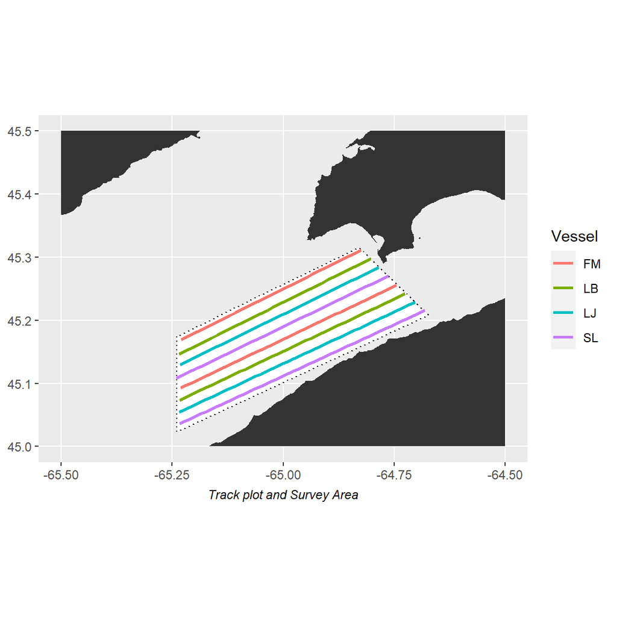

4 commercial purse seiners conducted this fishing survey on 09/10/2023 starting at 19:00:00, which was 2.12 hours before hide tide.

All vessels ran two transects each in the Main Survey Box.

There was a plankton tow and replicate conducted and CTD cast by Lady Janice II.

No tags were applied during this survey.

Since no fish were caught, no samples were obtained for target strength estimation.

### Tides Tables

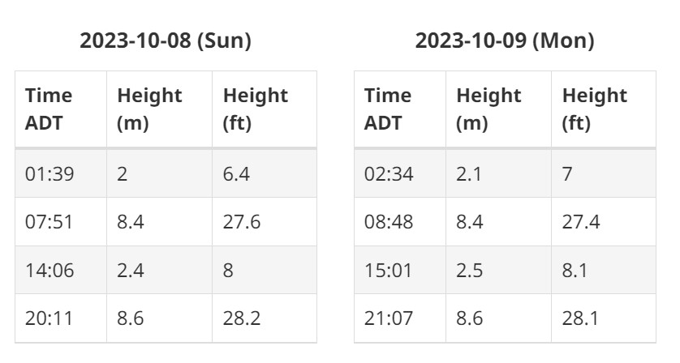

[figure not shown]

Tide Schedule for Margaretsville NS, Station #315m Source: www.waterlevels.gc.ca

### Acoustic Equipment

Each vessel was equipped with a Simrad ES38-18/200-18C combi (2-in-1) transducer prior to the survey that contains a 38kHz split beam and 200 kHz single beam transducer. Data was logged to the computer hard-drive for post-processing. All participating boats were calibrated on 38kHz before the survey.

## Survey Results

### Main Results

The results are subject to change as DFO will re-evaluate data editing, area estimation and apply a target strength.

**Preliminary biomass prediction for Scots Bay using standardized parallel transects is 3,388mt, and with turnover applied 2,971mt.**

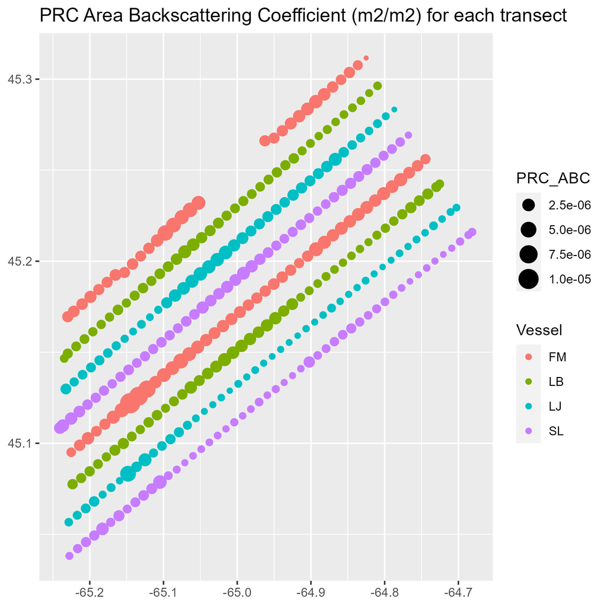

### Transect Details

Table 1: Transect Details

| Vessel | Transect # | Date/Time Start | Date/Time End | Start Lon | Start Lat | End Lon | End Lat | Location | Distance (km) | Speed |
| --- | --- | --- | --- | --- | --- | --- | --- | --- | --- | --- |
| FM | T01 | 2023-10-09 23:53:49 | 2023-10-10 02:31:34 | -65.231 | 45.093 | -64.745 | 45.256 | SB | 42.47 | 8.72 |
| FM | T02 | 2023-10-10 03:01:27 | 2023-10-10 05:14:58 | -64.825 | 45.312 | -65.230 | 45.170 | SB | 36.73 | 8.91 |
| LB | T01 | 2023-10-09 22:44:32 | 2023-10-10 01:28:49 | -65.233 | 45.074 | -64.725 | 45.242 | SB | 44.27 | 8.73 |
| LB | T02 | 2023-10-10 02:03:11 | 2023-10-10 04:22:02 | -64.803 | 45.298 | -65.235 | 45.147 | SB | 38.08 | 8.89 |
| LJ | T01 | 2023-10-09 22:50:54 | 2023-10-10 01:44:13 | -65.235 | 45.055 | -64.703 | 45.229 | SB | 46.23 | 8.64 |
| LJ | T02 | 2023-10-10 02:14:47 | 2023-10-10 04:40:46 | -64.784 | 45.284 | -65.232 | 45.130 | SB | 39.23 | 8.71 |
| SL | T01 | 2023-10-09 23:50:36 | 2023-10-10 02:46:36 | -65.234 | 45.036 | -64.681 | 45.216 | SB | 48.98 | 9.02 |
| SL | T02 | 2023-10-10 03:15:50 | 2023-10-10 05:51:28 | -64.763 | 45.271 | -65.240 | 45.108 | SB | 42.76 | 8.90 |

### Survey Summary

Table 2: Acoustic Survey Results

| Vessel | Transect No. | Target Strength (db/kg) | Mean Sa (/m2) | Biomass Density (kg/m2) |
| --- | --- | --- | --- | --- |
| FM | T01 | -35.5 | -55.551 | 0.010 |
| FM | T02 | -35.5 | -56.311 | 0.008 |
| LJ | T02 | -35.5 | -58.246 | 0.005 |
| SL | T02 | -35.5 | -58.363 | 0.005 |
| LB | T01 | -35.5 | -58.715 | 0.005 |
| LB | T02 | -35.5 | -59.540 | 0.004 |
| SL | T01 | -35.5 | -61.520 | 0.003 |
| LJ | T01 | -35.5 | -62.234 | 0.002 |

Note:  
Transects are listed from greatest to least backscatter.

Table 3: Survey Summary Table

| Layer | Target Strength | Area (km2) | Mean Sa | Density (kg/m2) | Biomass (tons) | Percent Area | Percent Biomass | Standard Error (tons) | Standard Error (%) |
| --- | --- | --- | --- | --- | --- | --- | --- | --- | --- |
| Main Box | -35.5 | 661 | -58.4032 | 0.0053 | 3,387.515 | NA | NA | 624.91 | 18.45 |
| Northern Box | NA | 77 | NA | NA | NA | NA | NA | NA | NA |
| Eastern Box | NA | NA | NA | NA | NA | NA | NA | NA | NA |

### Greatest Biomass Densities

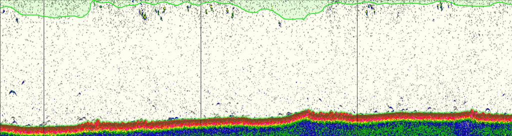

A snip from the transect with the greatest biomass density (kg/m2)

The single point with the largest biomass density (kg/m2) was recorded by **FM**, at the following location:

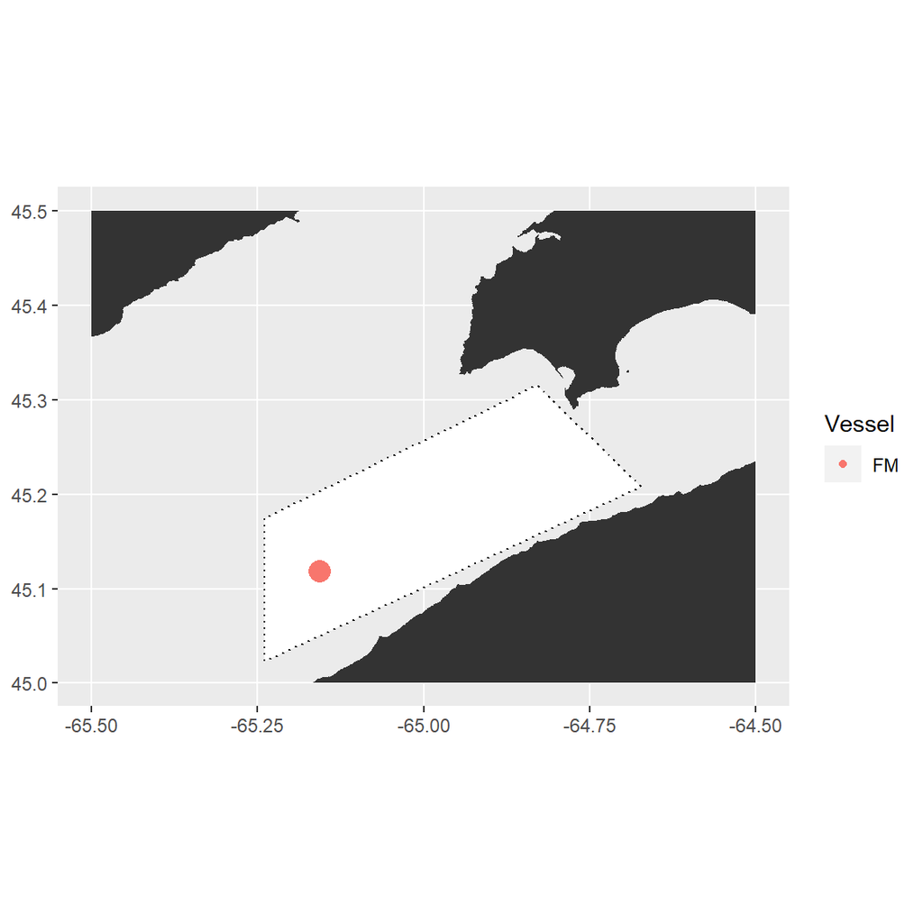

The transect with the greatest average biomass density (kg/m2) was recorded by **FM**, at the following location:

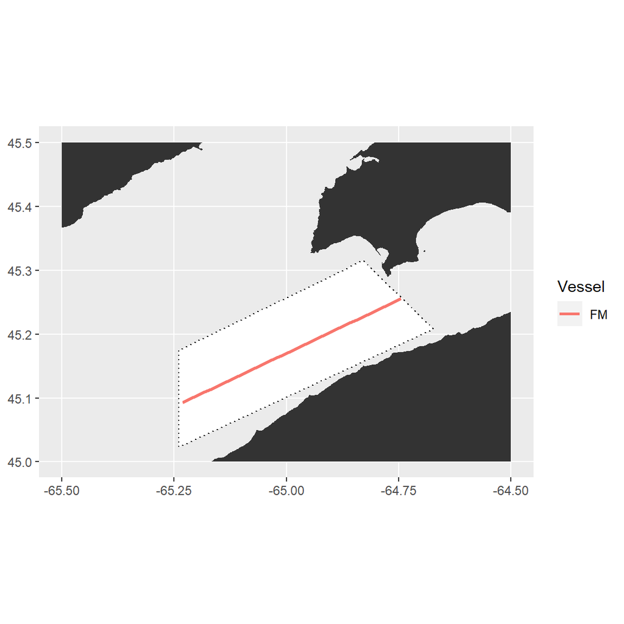

### Annual Summaries

Table 4: Annual Comparison Table

| Ground | Survey Number | Current Year Survey Date | Current Year HSC Estimate | Current Year HSC Turnover Adjusted | Previous Year Survey Date | Previous Year HSC Estimate | Previous Year HSC Turnover Adjusted | Previous Year DFO Estimate | Previous Year DFO Turnover Adjusted |
| --- | --- | --- | --- | --- | --- | --- | --- | --- | --- |
| Scots Bay | 1 | 2023-05-22 | 40,856.000 | 40,856 | 2022-05-29 | 92,542 | 92,542 | 99,092 | 99,092 |
| Scots Bay | 2 | 2023-06-06 | 113,767.329 | 108,783 | 2022-06-12 | 93,163 | 80,663 | 113,792 | 100,407 |
| Scots Bay | 3 | 2023-06-18 | 34,279.387 | 15,158 | 2022-06-26 | 30,535 | 17,624 | 29,429 | 13,709 |
| Scots Bay | 4 | 2023-07-02 | 11,744.776 | 5,113 | 2022-07-10 | 9,886 | 5,432 | 7,892 | 3,515 |
| Scots Bay | 5 | 2023-07-16 | 19,282.634 | 17,575 | 2022-07-26 | 11,954 | 10,869 | 11,402 | 10,536 |
| Scots Bay | 6 | 2023-07-30 | 4,549.933 | 1,904 | 2022-08-07 | 4,900 | 2,901 | 6,150 | 4,248 |
| Scots Bay | 7 | 2023-08-13 | 4,298.806 | 3,616 | 2022-08-21 | 4,094 | 3,225 | 4,688 | 3,656 |
| Scots Bay | 9 | 2023-09-10 | 3,053.669 | 2,916 | 2022-09-18 | 7,275 | 4,212 | 7,283 | 0 |
| Scots Bay | 10 | 2023-09-24 | 3,419.932 | 2,997 | 2022-10-03 | 4,573 | 3,613 | 4,152 | 0 |
| Scots Bay | 8 | 2023-08-27 | 2,896.659 | 2,300 | 2022-09-05 | 20,439 | 19,939 | 21,420 | 20,848 |
| Scots Bay | 11 | 2023-10-09 | 3,387.515 | 2,971 | NA | NA | NA | NA | NA |

Table 5: Annual Summary Table

| Year | Ground | HSC Estimate | HSC Turnover Adjusted | DFO Estimate | DFO Turnover Adjusted |
| --- | --- | --- | --- | --- | --- |
| 2022 | Scots Bay | 279,361.0 | 241,020 | 305,300 | 256,011 |
| 2023 | Scots Bay | 241,536.6 | 204,189 | NA | NA |

## Tagging, Plankton, and CTD Data

### Tag Data

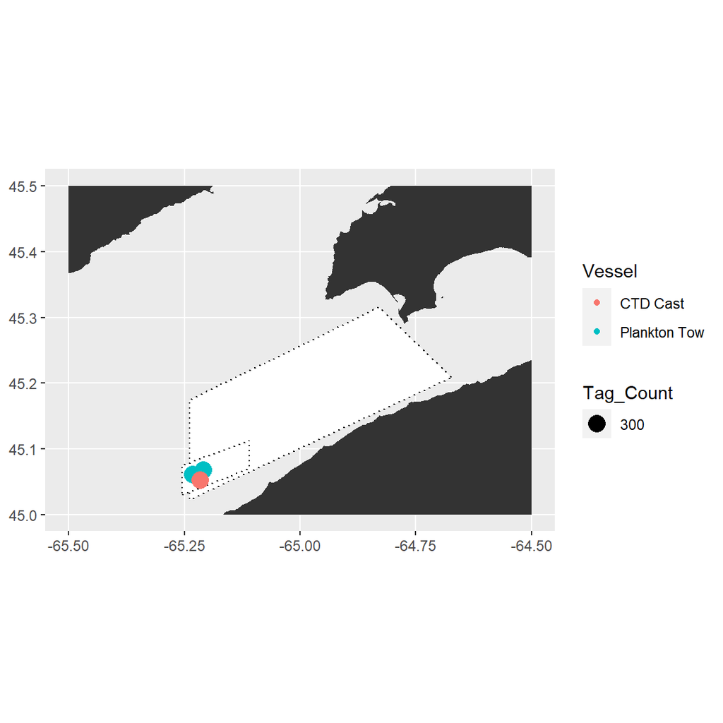

| Vessel | Tags |
| --- | --- |

### Plankton Data

#### Tow Summary Table

|  | Tow 1 | Tow 2 |
| --- | --- | --- |
| **Base Details** |  |  |
| Vessel | Lady Janice II | Lady Janice II |
| Set Number | SB2023-19 | SB2023-20 |
| Ground | SB | SB |
| Date | 09/10/2023 | 09/10/2023 |
| Wind Direction (km/h) | SE | SE |
| Swell (m) | 0 | 0 |
| Air Temp (c) | 12 | 12 |
| **Tow Details** |  |  |
| Tow Start | 17:40:00 | 17:56:00 |
| Tow End | 17:50:00 | 18:06:00 |
| Start Lat | 45.06083 | 45.06750 |
| End Lat | 45.07361 | 45.06167 |
| Start Lon | -65.23194 | -65.20861 |
| End Lon | -65.22556 | -65.21167 |
| Avg Tow Depth (m) | NA | NA |
| Speed | 3.7 | 1.6 |
| Heading | 42 | 200 |
| Tide Direction | with | against |
| **Other Data Collection** |  |  |
| Flow Start | 531588 | 554898 |
| Flow End | 554898 | 594023 |
| No. Revolutions | 23310 | 39125 |
| Distance (m) | 626.4096 | 1051.4061 |
| Volume | 1967.866 | 3302.992 |
| Secchi Disappear (m) | 7 | 7 |
| Secchi Reappear (m) | 6 | 6 |

### CTD Data

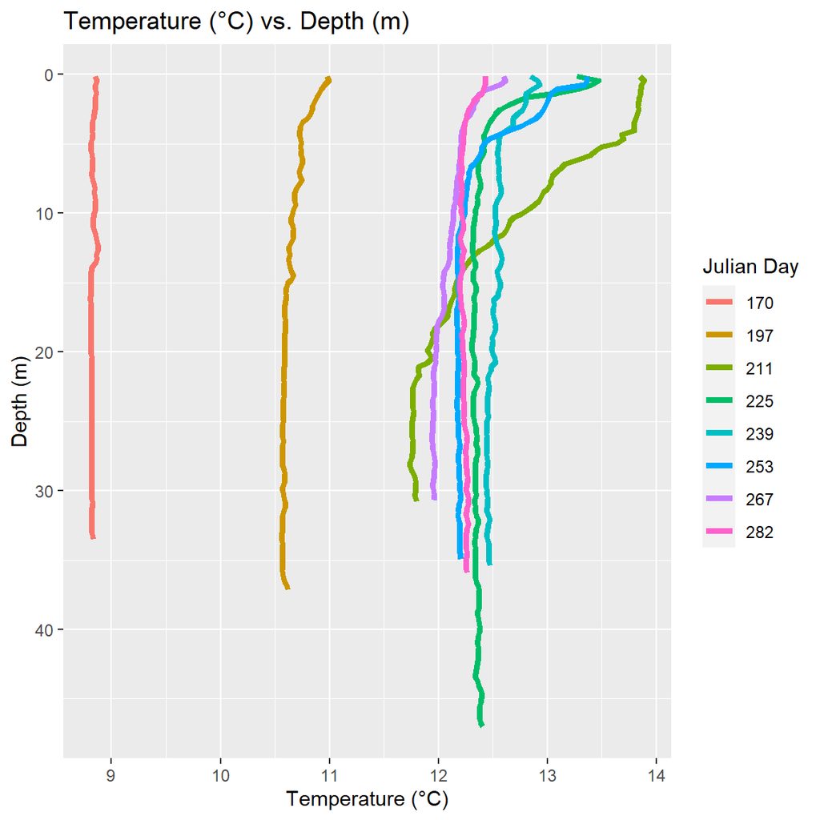

#### Sea surface temperatures

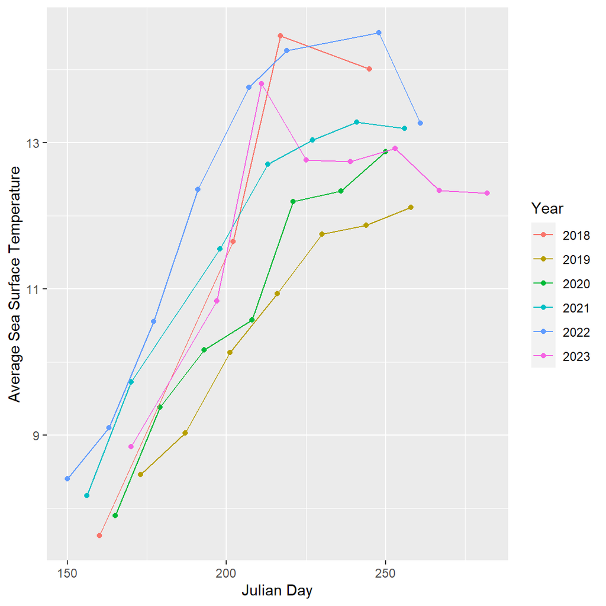

Annual average sea surface temperatures (SST) for Scots Bay.

## Vessel Performance

### Speed

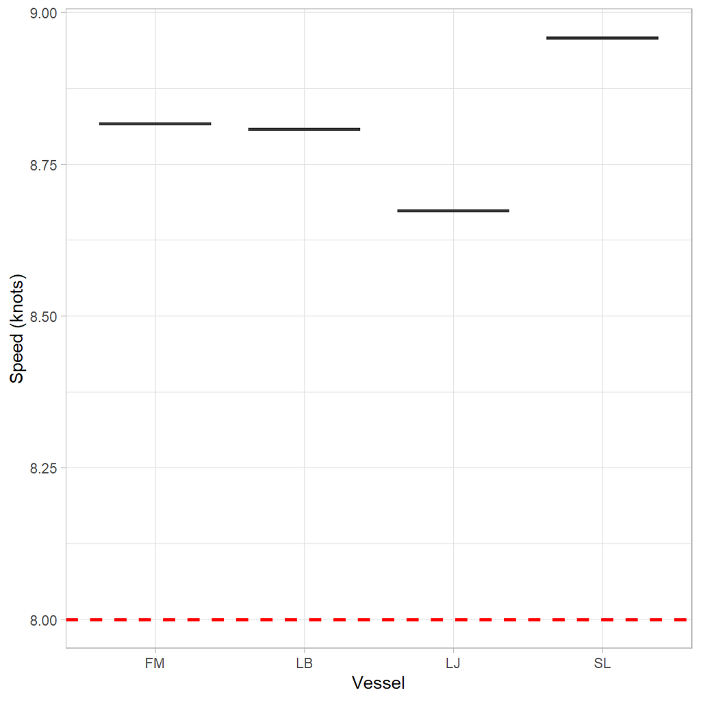

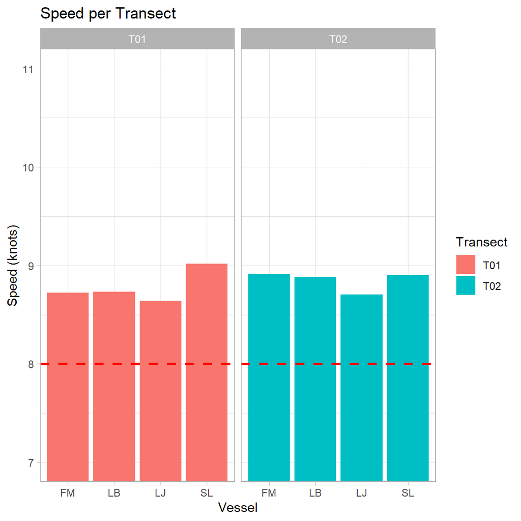

Average vessel speed was 8.81. This is above the 8 knot requirement; vessels are urged to slow down to prevent backscatter noise from interfering with the acoustic data.

### Distance

[figure not shown]

No significant distance was cut from the planned lines; vessels covered the planned area well.